# An Analysis of Video Game Sales and Ratings

## Introduction

Video games are a huge part of today's society, from rising popularity in E-Sports to increasing demand for video games for entertainment. Video games have been around for a long time, but only recently have sales really begun to break records. Every year, hundreds of games release, but only few become popular. It seems that every year, the bar on what makes a game "good" is set higher. The current best selling video game is Minecraft, with [over 200,000,000 sales worldwide](https://en.wikipedia.org/wiki/List_of_best-selling_video_games).

So that raises the question of what makes a video game popular? Is it the ratings by critics? Is it the time of year the game relased? Is it the console the game is released on? I will also be analyzing indivual game's completion times to determine if there is a relationship between game length and sales. All of these metrics will be measured by tracking effect on sales as a function of rating, platform, release time of year, developer, publisher, and time to beat. I am hoping to find some kind of trends to see what makes a video game sell well. The challenges associated with finding a trend will be normalizing sales numbers between different years because for example, a game that did extremely well in 2002 would most likely not sell as well as a game that did average in 2016 due to the increasing popularity of video games.

I am expecting to find a strong relationship between developer and sales, even if a game has bad ratings, I expected that a developer with a strong reputation such as EA with a mediocre game will beat a perfect score game from another less known developer (indie). I will form a proper hypothesis after exploratory data analysis.

This tutorial will focus on video games released between 2000 and 2019 in the United States to avoid games with insufficient data and avoid attributing US Ratings (Metacritic) to overseas sales.

## The Data

### Primary Dataset: Video game ratings from Metacritic.com

The primary dataset will need to be scraped manually by loading all pages from Metacritic.com and pulling the data from the search page. This will be done using an algorithm by [Julius Johnson](https://github.com/JuliusJohnson). The algorithm used can be found [here](https://github.com/JuliusJohnson/Metacritic_Game_Scrapper_2020/blob/master/mScrapper.py). I made slight modifications to the algorithm so that it collects all data from 2000 to 2021 and added some null checks since it kept crashing. This dataset will be used to the strength of reviews effect on sales. **This dataset is complete and has very few missing at random values for games that have no user reviews**

The fields of this dataset are:

- Name - Name of the game
- Date - Release date of game in the US
- Platform - Platform of the game (i.e. PC, PS4, XOne, etc.)
- score - Critic score of the game on a scale from 1-100
- userscore - Users score the game on a scale from 1-10
- url - url of game page - will be discarded

Metacritic has their own interesting lists, ranking games between genres and consoles. You can explore their reviews on [their website](https://www.metacritic.com/game)

### Tertiary Dataset: Video game sales from Vgchartz

This dataset, scraped from Vgchartz in April of 2019, and downloaded from kaggle.com, represents a list of about 11563 unique games on every platform that game released. An issue with this dataset is it's age, going up to only 2019 and not including the latest games, so we cannot measure the effect of COVID-19 on video game sales. I originally intended to scrape the data again using the same algorithm used for this dataset, but as of 07/16/2021, VGChartz is returning a 403 when I attempt to scrape. This dataset will be used to get sales metrics for games and compare them to developer/publisher and completion times (with the other tertiary dataset). **Not all developers release video game sales metrics, so a subset of this dataset will be analyzed where the data exists. The missingness of the data is Missing At Random since it is a developers decision to not publicize sales**

The fields of this dataset are:

- Rank - Ranking of overall sales - Will be discarded
- Name - Name of the game
- Platform - Platform of the game (i.e. PC, PS4, XOne, etc.)
- Genre - Genre of the game
- ESRB Rating - ESRB Rating of the game
- Publisher - Publisher of the game
- Developer - Developer of the game
- Critic Score - Critic score of the game from 10 - Will be discarded in favor of metacritic score
- User Score - Users score the game from 10 - Will be discarded in favor of metacritic score
- Total Shipped - Total shipped copies of the game
- Global_Sales - Total worldwide sales (in millions) - Will be discarded since we are focusing on the U.S.
- NA_Sales - Sales in North America (in millions)
- PAL_Sales - Sales in Europe (in millions) - Will be discarded since we are focusing on the U.S.
- JP_Sales - Sales in Japan (in millions) - Will be discarded since we are focusing on the U.S.
- Other_Sales - Sales in the rest of the world (in millions) - Will be discarded since we are focusing on the U.S.
- Year - Year of release of the game - Will be discarded since our primary dataset has it

I chose this dataset because it is the most complete collection of video game sales data online ranging back to 1980 with the Atari 2600. This will allow us to trim down the dataset to our chosen range (2000-2019). The reason I am removing the metacritic scores is because I am going to scrap the latest data from metacritic myself.

A link to the dataset can be found [here](https://www.kaggle.com/ashaheedq/video-games-sales-2019?select=vgsales-12-4-2019.csv)

### Tertiary Dataset: HowLongToBeat.com Completion Times

This dataset is the latest of the two, going up to 2020. This dataset includes a lot more games that were NOT published (PC Indie games on sites such as [itchio](https://itch.io/)) Due to this, a lot of this dataset will be disregarded since this tutorial is only analyzing published games that have public sales metrics. This dataset will be inner joined into the primary dataset to get time to completion for games to determine if there is an effect on sales. **This dataset is has some missing at random entries that cannot have completion times given their nature (multiplayer only, mod, DLC, etc.) These games will be disregarded**

The fields of this dataset are:

- id - Game ID from the website.
- title - Game name.
- main_story - Average completion time of 'Main Story' in hours. - Will be discarded in favor of all_styles, which is the average of all completion times
- main_plus_extras - Average completion time of 'Main + Extras' in hours. - Will be discarded in favor of all_styles, which is the average of all completion times
- completionist - Average completion time of 'Completionist' in hours. - Will be discarded in favor of all_styles, which is the average of all completion times
- all_styles - Average completion time of 'All Styles' in hours.
- coop - Average completion time of 'Co-Op' in hours. - Will be discarded since the dataset is focusing on video games playtime in singleplayer
- versus - Average completion time of 'Vs.' in hours. - Will be discarded since the dataset is focusing on video games playtime in singleplayer
- type - Type entry to differentiate DLC/Expansion, Mod, and ROM Hack from regular game entries. - Discarded since it is irrelevant when joined with the primary dataset
- developers - Comma-space separated list of all developers of an entry. - Will be used for focused analysis of HLTB data
- publishers - Comma-space separated list of all publishers of an entry. - Will be used for focused analysis of HLTB data
- platforms - Comma-space separated list of all platforms an entry is available on. - Discarded since Vgchartz has more reliable data
- genres - Comma-separated list of genres for an entry. - Discarded since Vgchartz has more reliable data
- release_na - Release date in North America (if available). - Will be used for focused analysis of HLTB data
- release_eu - Release date in Europe (if available). - Discarded since Vgchartz has more reliable data
- release_jp - Release date in Japan (if available). - Discarded since Vgchartz has more reliable data

A link to the dataset can be found [here](https://www.kaggle.com/kasumil5x/howlongtobeat-games-completion-times)

## Data Collection

### Imports for data manipulation and analysis

In order to evaluate the trend between video game ratings and sales, we will be importing pandas for dataframe storage, numpy for matrix manipulation, matplotlib for plotting, seaborn for violin plots, and sklearn for linear regression models.

```python
import pandas as pd
import numpy as np
from datetime import datetime
import datetime
import matplotlib.pyplot as plt
from matplotlib.pyplot import figure
import scipy, pylab
import statsmodels.api as sm
import statsmodels.formula.api as smf
import seaborn as sns
from sklearn.datasets import load_digits
from sklearn.tree import DecisionTreeClassifier
import sklearn.model_selection as ms
import sklearn.metrics as met
from sklearn import datasets, neighbors, linear_model
from sklearn.neighbors import KNeighborsClassifier
from sklearn.metrics import classification_report, confusion_matrix
from sklearn.model_selection import train_test_split
from sklearn.metrics import roc_auc_score
from sklearn.svm import SVC
from sklearn.model_selection import GridSearchCV
```

### Scraping video game rating data from Metacritic 2000-2021

This algorithm from [Julius Johnson](https://github.com/JuliusJohnson) scrapes all data from metacritic search pages (it does not crawl each link individually so it does not get teriary information such as genre and developer, but that can be joined from the other dataset). It uses pandas and beautifulsoup to scrape the data into a dataframe and saves it as a csv. The only missing data are games that are still pending review, which are not many. I chose this algorithm because it works fairly quickly.

```python
import requests, csv, pandas as pd, pprint, time
from bs4 import BeautifulSoup
import lxml,html5lib

data_dict = {'name':[], 'date':[], 'platform': [], 'score':[], 'url':[], 'userscore':[]} # Data Structure

def webpage(pageNum,year): #function that navigates the metacritic SRP(Search Results Pages) based on the page number and the year
    url = 'https://www.metacritic.com/browse/games/score/metascore/year/all/filtered?year_selected='+ str(year) +'&distribution=&sort=desc&view=condensed&page='+ str(pageNum)
    userAgent = {'User-agent': 'Mozilla/5.0'}
    response = requests.get(url, headers=userAgent)
    return response

def numberPages(response): # Helper Function that determines how many pages are in a SRP to know how many times to run scrapper function
    soup = BeautifulSoup(response.text, 'html.parser')
    pages = soup.find_all('li', {"class":"page last_page"})
    if (len(pages) > 0):
        pagesCleaned = pages[0].find('a', {"class":"page_num"})
        return (pagesCleaned.text)
    else:
        return ""



def scrapper(num_loops,content):
    tblnum = 0
    while tblnum < num_loops:
        #get Game name
        table_rows = content[tblnum].find_all('tr')
        for tr in table_rows:
            td = tr.find_all('td')
            for a in td[1].find_all('a', {"class":"title"}):
                data_dict['name'].append(a.find('h3').text)
                #print(a.find('h3').text)

        #get Game release date
        table_rows = content[tblnum].find_all('tr')
        for tr in table_rows:
            td = tr.find_all('td')
            for date in td[1].find_all('span',{"class":""}):
                data_dict['date'].append(date.text)
                #print(date.text)

        #get platform
        table_rows = content[tblnum].find_all('tr')
        for tr in table_rows:
            td = tr.find_all('td')
            for platform in td[1].find_all('span',{"class":"data"}):
                data_dict['platform'].append(platform.text.strip())
                #print(platform.text.strip())

        #get Game score
        table_rows = content[tblnum].find_all('tr')
        for tr in table_rows:
            td = tr.find_all('td')
            for user in td[0].find_all('div',{"class":"metascore_w"}):
                data_dict['score'].append(user.text.strip())
                #print(user.text.strip())

        #getting game url
        table_rows = content[tblnum].find_all('tr')
        for tr in table_rows:
            td = tr.find_all('td')
            for a in td[1].find_all('a', {"class":"title"} ,href=True):
                data_dict['url'].append(a['href'])
                #print(a['href'])

        #get Game userscore
        table_rows = content[tblnum].find_all('tr')
        for tr in table_rows:
            td = tr.find_all('td')
            for score in td[1].find_all('div', {"class":"metascore_w"}):
                data_dict['userscore'].append(score.text)
                #print(score.text)
        tblnum += 1

def pages(lastPageNum, year): #Function that returns the html(code) and initiates the web scrapper
    currentPage = 0
    while currentPage < int(lastPageNum):
        url = url = 'https://www.metacritic.com/browse/games/score/metascore/year/all/filtered?year_selected='+ str(year) +'&distribution=&sort=desc&view=condensed&page=' + str(currentPage)
        userAgent = {'User-agent': 'Mozilla/5.0'}
        response = requests.get(url, headers=userAgent)
        soup = BeautifulSoup(response.text, 'html.parser')
        content = soup.find_all('table')

        num_loops = len(content)
        #print(num_loops)
        scrapper(num_loops,content)
        #print(data_dict)
        currentPage += 1
        #print(currentPage)
        time.sleep(6)

def is_integer(n):
    try:
        float(n)
    except ValueError:
        return False
    else:
        return float(n).is_integer()

def main():
    years = list(range(2000,2021)) # Year
    for year in years:
        numPage = (numberPages(webpage(0,year)))
        if (numPage == 0 or numPage is None or not is_integer(numPage)):
            print("No data")
        else:
            pages(int(numPage),year)
            time.sleep(5)
            # print(year)
    xData = (pd.DataFrame.from_dict(data_dict))
    xData.to_csv('mc.csv')

# file1= open("sample_html","w")
# file1.write(webpage(0,2020).text)
# file1.close()
# #print(webpage(0,2020).text)
main()
```

### Importing video game rating data from Metacritic 2000-2021

```python
# Fetching data
video_game_metacritic_df = pd.read_csv("vgmetacritic.csv")

# Sorting by name
video_game_metacritic_df = video_game_metacritic_df.sort_values(by=['name'], ascending=False).reset_index()

# Since this is the primary dataset and is mostly complete, I will only drop index rank, and url
video_game_metacritic_df = video_game_metacritic_df.drop(columns=['index', 'Unnamed: 0', 'url'])

# Better column naming
video_game_metacritic_df.columns = ['Title', 'Release_Date', 'Platform', 'Critic_Score', 'User_Score']

# Lastly, filter until 2019 since our other data only goes up to 2019
video_game_metacritic_df['Release_Date'] = pd.to_datetime(video_game_metacritic_df['Release_Date'], format='%d-%b-%y')
video_game_metacritic_df = video_game_metacritic_df[(video_game_metacritic_df['Release_Date'] <= '2019-07-31')]

pd.set_option('display.max_rows', video_game_metacritic_df.shape[0]+1)
video_game_metacritic_df.head() # Display
```

|  | Title | Release_Date | Platform | Critic_Score | User_Score |
| --- | --- | --- | --- | --- | --- |
| 0 | xXx | 2002-07-31 | Game Boy Advance | 50 | 5 |
| 2 | uDraw Studio | 2010-11-14 | Wii | 71 | tbd |
| 3 | theHunter: Call of the Wild | 2017-02-16 | PC | 64 | 7.1 |
| 4 | oOo: Ascension | 2018-05-25 | Xbox One | 70 | 7.3 |
| 5 | nail'd | 2010-11-30 | PC | 69 | 7.6 |

#### Analysis

It can be seen here that we successfully scraped title, release date (U.S.), platform, and both critic and user scores. There are no missing critic scores but we will need to handle the missing user scores in the next section.

### Importing video game sales data from VGChartz dataset

```python
# Fetching data
video_game_vgchartz_df = pd.read_csv("vgsales2019.csv")

# Sorting by name
video_game_vgchartz_df = video_game_vgchartz_df.sort_values(by=['Name'], ascending=False).reset_index()

# Dropping old index, rank, basename
# Reason: I will be using the Name as the primary key
video_game_vgchartz_df = video_game_vgchartz_df.drop(columns=['index', 'Rank', 'basename'])

# Maintaining time period of 2000-2019
video_game_vgchartz_df = video_game_vgchartz_df[(video_game_vgchartz_df['Year'] >= 2000) & (video_game_vgchartz_df['Year'] <= 2019)]

# Also dropping score, non-US sales data, and extra data that got imported including copies shipped since we do not know where they were shipped (global or US)
video_game_vgchartz_df = video_game_vgchartz_df.drop(columns=['VGChartz_Score', 'PAL_Sales', 'JP_Sales', 'Total_Shipped', 'Global_Sales', 'Other_Sales', 'Last_Update', 'url', 'status', 'Vgchartzscore', 'img_url' , 'Critic_Score', 'User_Score'])

# Better column naming
video_game_vgchartz_df.columns = ['Title', 'Genre', 'ESRB_Rating', 'Platform', 'Publisher', 'Developer', 'NA_Sales', 'Year']

# Datetime
video_game_vgchartz_df['Year'] = pd.to_datetime(video_game_vgchartz_df['Year'], format='%Y')

pd.set_option('display.max_rows', video_game_vgchartz_df.shape[0]+1)
video_game_vgchartz_df.head() # Display
```

|  | Title | Genre | ESRB_Rating | Platform | Publisher | Developer | NA_Sales | Year |
| --- | --- | --- | --- | --- | --- | --- | --- | --- |
| 2 | yOm_fury | Action | NaN | XBL | Microsoft | jojito | NaN | 2009-01-01 |
| 3 | yOm | Action | NaN | XBL | Microsoft | jojito | NaN | 2009-01-01 |
| 4 | xFart | Misc | NaN | XBL | Microsoft | arcarocket | NaN | 2009-01-01 |
| 5 | vib-ribbon | Misc | NaN | PS | Sony Computer Entertainment | NanaOn-Sha | NaN | 2000-01-01 |
| 6 | unRevolutionary | Shooter | NaN | XBL | Microsoft | julio9 | NaN | 2009-01-01 |

#### Analysis

It can be seen here that we successfully imported all relevant sales data, but there is a lot of missing data. This is to be expected since not all developers release sales metrics. Since we are measuring sales by success, we will need to figure out a way to deal with this in the next section.

### Importing video game completion time from HLTB dataset

```python
# Fetching data
video_game_hltb_df = pd.read_csv("vgtimetobeat.csv")

# Sorting by name
video_game_hltb_df = video_game_hltb_df.sort_values(by=['title'], ascending=False).reset_index()

# Dropping old index, id, platforms, genres, and release dates
# The first two because I will be making new indicies and the last 4 because the other datasets have that data.
video_game_hltb_df = video_game_hltb_df.drop(columns=['index', 'id', 'platforms', 'genres', 'release_eu', 'release_jp'])

# Also dropping all completion times in favor of the completion time for all styles, which is the average between all
video_game_hltb_df = video_game_hltb_df.drop(columns=['main_story', 'main_plus_extras', 'completionist', 'coop', 'versus', 'type'])

# Lastly dropping developers and publishers since I will be using the dev/pub data from VGChartz as the site is more reputable
video_game_hltb_df = video_game_hltb_df.drop(columns=['developers', 'publishers'])

# Better column naming
video_game_hltb_df.columns = ['Title', 'Average_Time_To_Beat_Between_All_Playstyles', 'Release_Date']

video_game_hltb_df['Release_Date'] = pd.to_datetime(video_game_hltb_df['Release_Date'], format='%Y-%m-%d')

# Maintaining time period of 2000-2019
video_game_hltb_df = video_game_hltb_df[(video_game_hltb_df['Release_Date'] >= '2000-01-01') & (video_game_hltb_df['Release_Date'] <= '2019-07-31')]

pd.set_option('display.max_rows', video_game_hltb_df.shape[0]+1)
video_game_hltb_df.head() # Display
```

|  | Title | Average_Time_To_Beat_Between_All_Playstyles | Release_Date |
| --- | --- | --- | --- |
| 0 | ＜/reality＞ | NaN | 2017-04-18 |
| 1 | 音灵 INVAXION | NaN | 2018-12-19 |
| 2 | 猫肉「Cat Meat」 | 4.0 | 2017-04-21 |
| 4 | ШП - ShP | 1.5 | 2017-10-31 |
| 5 | Сartoonway: Mini Cars | NaN | 2018-05-18 |

#### Analysis

Lastly, the HLTB dataset is the largest of the three because it includes data on indie and non-published games. Because of this, it has a lot of **Missing at random** values. These will likely be dropped in the next section.

## Data Tidying

Now that we have all three tables, we can tidy them up individually by deciding how to deal with missing values and then joining them based on video game title. First, we will look at how to deal with the missing user reviews from the metacritic data. After that, we will review the VGChartz dataset missing sales data. Lastly, we will review The HLTB.com dataset to see if any of the games that have missing completion times are in the primary metacritic dataset. We are doing an inner join between the two, so fining the missing data should be easy.

### Tidying Metacritic dataset

The best course of action for the missing user reviews in the metacritic dataset is to convert them to NaN to prevent errors. Since critic score is never missing, we will only have to review the user score column.

```python
video_game_metacritic_df = video_game_metacritic_df.replace('tbd', np.nan) #For tbd user ratings
video_game_metacritic_df.info()
```

```
<class 'pandas.core.frame.DataFrame'>
Int64Index: 11813 entries, 0 to 13109
Data columns (total 5 columns):
 #   Column        Non-Null Count  Dtype
---  ------        --------------  -----
 0   Title         11813 non-null  object
 1   Release_Date  11813 non-null  datetime64[ns]
 2   Platform      11813 non-null  object
 3   Critic_Score  11813 non-null  int64
 4   User_Score    10997 non-null  object
dtypes: datetime64[ns](1), int64(1), object(3)
memory usage: 553.7+ KB
```

### Tidying VGChartz dataset

The VGChartz has a lot of missing data since, as stated before, not all developers release sales metrics publicly. If a title does not have US Sales metrics, I will be dropping it so that I am not introducing any bias by digging deeper into certain popular titles to fill in missing data. These entries will be **Missing at random** since their missingness is attributed to the publisher's choice and is out of my control. There are also some entries with missing developer data, but there is always a publisher. We will also be fixing platform names so that they match between the datasets when we join.

```python
# Getting indicies of rows that have both copies shipped and NA_Sales as NaN to remove them
video_game_vgchartz_df = video_game_vgchartz_df.replace('GBA', 'Game Boy Advance') #For Game Boy
video_game_vgchartz_df = video_game_vgchartz_df.replace('PS', 'PlayStation') #For Playstation
video_game_vgchartz_df = video_game_vgchartz_df.replace('PS2', 'PlayStation 2') #For Playstation
video_game_vgchartz_df = video_game_vgchartz_df.replace('PS3', 'PlayStation 3') #For Playstation
video_game_vgchartz_df = video_game_vgchartz_df.replace('PS4', 'PlayStation 4') #For Playstation
video_game_vgchartz_df = video_game_vgchartz_df.replace('PS5', 'PlayStation 5') #For Playstation
video_game_vgchartz_df = video_game_vgchartz_df.replace('XOne', 'Xbox One') #For Xbox
video_game_vgchartz_df = video_game_vgchartz_df.replace('X360', 'Xbox 360') #For Xbox
video_game_vgchartz_df = video_game_vgchartz_df.replace('XB', 'Xbox') #For Xbox
video_game_vgchartz_df = video_game_vgchartz_df.replace('PSV', 'PlayStation Vita') #For Vita
video_game_vgchartz_df = video_game_vgchartz_df.replace('WiiU', 'Wii U') #For Wii U
video_game_vgchartz_df = video_game_vgchartz_df.replace('NS', 'Switch') #For Switch
video_game_vgchartz_df = video_game_vgchartz_df.replace('GC', 'Gamecube') #For Gamedube
video_game_vgchartz_df = video_game_vgchartz_df.replace('N64', 'Nintendo 64') #For Nintendo 64
video_game_vgchartz_df = video_game_vgchartz_df.replace('DC', 'Dreamcast') #For Dreamcast
indicies = video_game_vgchartz_df[(video_game_vgchartz_df.NA_Sales.isna())].index
video_game_vgchartz_df.drop(indicies, inplace = True)
video_game_vgchartz_df.info()
```

```
<class 'pandas.core.frame.DataFrame'>
Int64Index: 11907 entries, 7 to 55777
Data columns (total 8 columns):
 #   Column       Non-Null Count  Dtype
---  ------       --------------  -----
 0   Title        11907 non-null  object
 1   Genre        11907 non-null  object
 2   ESRB_Rating  11356 non-null  object
 3   Platform     11907 non-null  object
 4   Publisher    11907 non-null  object
 5   Developer    11905 non-null  object
 6   NA_Sales     11907 non-null  float64
 7   Year         11907 non-null  datetime64[ns]
dtypes: datetime64[ns](1), float64(1), object(6)
memory usage: 837.2+ KB
```

#### Analysis

After a little tidying, we now have a very large list entries that have hard sales data (in USD) . There is also no more missing data in the Publisher column. The only missing data left that is not accounted for is the ESRB rating, but we can use the ratings that do exist to attempt to find trends.

### Tidying HLTB dataset

The HLTB has a lot of missing data because of it being an open source site where anyone can upload their completion times to certain games, published or not. Since we will be focusing on games that have a completion time (to determine if that has an affect on sales), we will be dropping any entries that do not have a completion time (these are usually multiplayer only DLCs and mods, which do not effect the base game's sales).

```python
# Getting indicies of rows that have missing Average_Time_To_Beat_Between_All_Playstyles
video_game_hltb_df_cleaned = pd.DataFrame(video_game_hltb_df)
indicies = video_game_hltb_df_cleaned[(video_game_hltb_df_cleaned.Average_Time_To_Beat_Between_All_Playstyles.isna())].index
video_game_hltb_df_cleaned.drop(indicies, inplace = True)
video_game_hltb_df_cleaned.info()
```

```
<class 'pandas.core.frame.DataFrame'>
Int64Index: 15479 entries, 2 to 35921
Data columns (total 3 columns):
 #   Column                                       Non-Null Count  Dtype
---  ------                                       --------------  -----
 0   Title                                        15479 non-null  object
 1   Average_Time_To_Beat_Between_All_Playstyles  15479 non-null  float64
 2   Release_Date                                 15479 non-null  datetime64[ns]
dtypes: datetime64[ns](1), float64(1), object(1)
memory usage: 483.7+ KB
```

#### Analysis

The HLTB dataset now has 0 missing values and we can begin joining the tables together

## Data Joining

### Joining the vchartz dataset

```python
# Joining metacritic and vchartz dataframes on title and platform
metacritic_vgchartz_df = pd.merge(video_game_metacritic_df, video_game_vgchartz_df, left_on=['Title', 'Platform'], right_on=['Title', 'Platform'], how='inner')
pd.set_option('display.max_rows', metacritic_vgchartz_df.shape[0]+1)
metacritic_vgchartz_df.info()

# Joining vchartz and hltb dataframes on title to get release dates
vgchartz_with_release_dates = pd.merge(video_game_vgchartz_df, video_game_hltb_df, left_on=['Title'], right_on=['Title'], how='inner')
vgchartz_with_release_dates.info()
```

```
<class 'pandas.core.frame.DataFrame'>
Int64Index: 5049 entries, 0 to 5048
Data columns (total 11 columns):
 #   Column        Non-Null Count  Dtype
---  ------        --------------  -----
 0   Title         5049 non-null   object
 1   Release_Date  5049 non-null   datetime64[ns]
 2   Platform      5049 non-null   object
 3   Critic_Score  5049 non-null   int64
 4   User_Score    4639 non-null   object
 5   Genre         5049 non-null   object
 6   ESRB_Rating   4907 non-null   object
 7   Publisher     5049 non-null   object
 8   Developer     5049 non-null   object
 9   NA_Sales      5049 non-null   float64
 10  Year          5049 non-null   datetime64[ns]
dtypes: datetime64[ns](2), float64(1), int64(1), object(7)
memory usage: 473.3+ KB
<class 'pandas.core.frame.DataFrame'>
Int64Index: 7386 entries, 0 to 7385
Data columns (total 10 columns):
 #   Column                                       Non-Null Count  Dtype
---  ------                                       --------------  -----
 0   Title                                        7386 non-null   object
 1   Genre                                        7386 non-null   object
 2   ESRB_Rating                                  7101 non-null   object
 3   Platform                                     7386 non-null   object
 4   Publisher                                    7386 non-null   object
 5   Developer                                    7386 non-null   object
 6   NA_Sales                                     7386 non-null   float64
 7   Year                                         7386 non-null   datetime64[ns]
 8   Average_Time_To_Beat_Between_All_Playstyles  5688 non-null   float64
 9   Release_Date                                 7386 non-null   datetime64[ns]
dtypes: datetime64[ns](2), float64(2), object(6)
memory usage: 634.7+ KB
```

### Joining the time to beat dataset

```python
final_vg_df = pd.merge(metacritic_vgchartz_df, video_game_hltb_df_cleaned, left_on=['Title'], right_on=['Title'], how='inner')
final_vg_df = final_vg_df.drop(columns=['Release_Date_y'])
pd.set_option('display.max_rows', final_vg_df.shape[0]+1)
final_vg_df.info()
```

```
<class 'pandas.core.frame.DataFrame'>
Int64Index: 3114 entries, 0 to 3113
Data columns (total 12 columns):
 #   Column                                       Non-Null Count  Dtype
---  ------                                       --------------  -----
 0   Title                                        3114 non-null   object
 1   Release_Date_x                               3114 non-null   datetime64[ns]
 2   Platform                                     3114 non-null   object
 3   Critic_Score                                 3114 non-null   int64
 4   User_Score                                   2979 non-null   object
 5   Genre                                        3114 non-null   object
 6   ESRB_Rating                                  3029 non-null   object
 7   Publisher                                    3114 non-null   object
 8   Developer                                    3114 non-null   object
 9   NA_Sales                                     3114 non-null   float64
 10  Year                                         3114 non-null   datetime64[ns]
 11  Average_Time_To_Beat_Between_All_Playstyles  3114 non-null   float64
dtypes: datetime64[ns](2), float64(2), int64(1), object(7)
memory usage: 316.3+ KB
```

## Data Visualization and Analysis

Now that our data is all together and separated into frames that have had their missing data dealt with, we can begin attempting to find trends in what makes a video game sell well. We will start by doing a simple plot of sales over time between consoles.

Our dependent variables are:

- Sales (USD)
- Critic Score

Our independent variables are:

- Release date
- Genre
- Time to beat
- Platform

First, we will start by analyzing the raw VGChartz data to find what platforms sell the best over time.

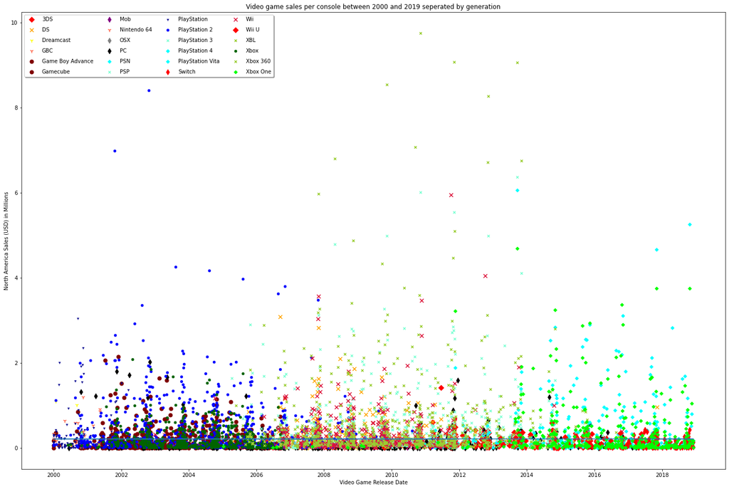

```python
from sklearn.linear_model import LinearRegression

fig, ax = plt.subplots(figsize=(24,16))

# Group by platform and generation
for label, group in vgchartz_with_release_dates.groupby(['Platform']):
    if ("Xbox" in label or "XBL" in label):
        if ("360" in label or "XBL" in label):
            ax.scatter(group['Release_Date'], group['NA_Sales'], label=label, marker="x", s=20, color='yellowgreen')
        elif ("One" in label):
            ax.scatter(group['Release_Date'], group['NA_Sales'], label=label, marker="D", s=20, color='lime')
        else:
            ax.scatter(group['Release_Date'], group['NA_Sales'], label=label, marker="o", s=20, color='darkgreen')
    elif ("PlayStation" in label or "PSN" in label or "PSP" in label):
        if ("4" in label or "PSN" in label or "Vita" in label):
            ax.scatter(group['Release_Date'], group['NA_Sales'], label=label, marker="D", s=20, color='cyan')
        elif ("3" in label or "PSP" in label):
            ax.scatter(group['Release_Date'], group['NA_Sales'], label=label, marker="x", s=20, color='aquamarine')
        elif ("2" in label):
            ax.scatter(group['Release_Date'], group['NA_Sales'], label=label, marker="o", s=20, color='blue')
        else:
            ax.scatter(group['Release_Date'], group['NA_Sales'], label=label, marker="1", s=20, color='darkblue')
    elif ("Wii U" == label):
        ax.scatter(group['Release_Date'], group['NA_Sales'], label=label, marker="D", s=50, color='red')
    elif ("Wii" == label):
        ax.scatter(group['Release_Date'], group['NA_Sales'], label=label, marker="x", s=50, color='crimson')
    elif ("Switch" == label):
        ax.scatter(group['Release_Date'], group['NA_Sales'], label=label, marker="d", s=50, color='red')
    elif ("Nintendo 64" == label):
        ax.scatter(group['Release_Date'], group['NA_Sales'], label=label, marker="1", s=50, color='tomato')
    elif ("Gamecube" == label):
        ax.scatter(group['Release_Date'], group['NA_Sales'], label=label, marker="o", s=50, color='maroon')
    elif ("GBC" == label):
        ax.scatter(group['Release_Date'], group['NA_Sales'], label=label, marker="1", s=50, color='tomato')
    elif ("3DS" == label):
        ax.scatter(group['Release_Date'], group['NA_Sales'], label=label, marker="D", s=50, color='red')
    elif ("DS" == label):
        ax.scatter(group['Release_Date'], group['NA_Sales'], label=label, marker="x", s=50, color='orange')
    elif ("Game Boy" in label):
        ax.scatter(group['Release_Date'], group['NA_Sales'], label=label, marker="o", s=50, color='maroon')
    elif ("Dreamcast" == label):
        ax.scatter(group['Release_Date'], group['NA_Sales'], label=label, marker="1", s=50, color='yellow')
    elif ("PC" == label):
        ax.scatter(group['Release_Date'], group['NA_Sales'], label=label, marker="d", s=50, color='black')
    elif ("OSX" == label):
        ax.scatter(group['Release_Date'], group['NA_Sales'], label=label, marker="d", s=50, color='grey')
    else:
        ax.scatter(group['Release_Date'], group['NA_Sales'], label=label, marker="d", s=50, color='purple')

# make and plot regression line.
years = np.array(vgchartz_with_release_dates["Release_Date"]).reshape(-1, 1)
sales = np.array(vgchartz_with_release_dates["NA_Sales"]).reshape(-1, 1)
reg = LinearRegression().fit(years, sales)
plt.plot(years, reg.intercept_ + reg.coef_ * sales, '-')

ax.legend(ncol=4,
           labelspacing=1.0,
           handletextpad=1.0, handlelength=2.0,
           fancybox=True, shadow=True)

ax.set_xlabel('Video Game Release Date')
ax.set_ylabel('North America Sales (USD) in Millions')
plt.title("Video game sales per console between 2000 and 2019 seperated by generation")
plt.show()
```

### Analysis

We will look deeper into this trend by binning our data by release quarters and standardize the values across the years using seaborn violin plot to show relative game performance based on quarter. Q1: Jan, Feb, Mar Q2: Apr, May, Jun Q3: Jul, Aug, Sep Q4: Oct, Nov, Dec

I am expecting to see higher average sales in Q4 across all years.

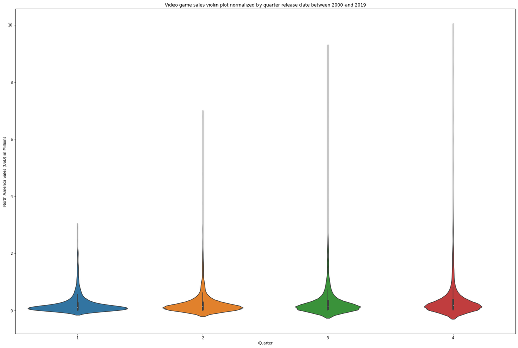

```python
binned_vg_sales = pd.DataFrame(vgchartz_with_release_dates)
binned_vg_sales['Qtr'] = pd.to_datetime(binned_vg_sales.Release_Date).dt.quarter

fig, ax = plt.subplots(figsize=(24,16))

sns.violinplot(x=binned_vg_sales.Qtr, y=binned_vg_sales.NA_Sales)

# Set proper labels for qtr and sales
ax.set_xlabel('Quarter')
ax.set_ylabel('North America Sales (USD) in Millions')
plt.title("Video game sales violin plot normalized by quarter release date between 2000 and 2019")
plt.show()
```

### Analysis

Here we can see our expected trend that games released in Q4, on average, sell better than games released in Q1, Q2, and Q3. We can see this by the higher mean and outside points in Q4 (red) plot. We will now do a statistical analysis of the plot data between sales and release quarter.

We will look at the best MONTH to release a game next to see if the hypothesis holds true over a year instead of by quarters.

```python
# Getting residual model
statistic_model = smf.ols(formula="NA_Sales ~ Qtr ", data=binned_vg_sales).fit()
print(statistic_model.summary())

# Pulling residual data from model
binned_vg_sales['predictedSales'] = statistic_model.resid
```

```
                            OLS Regression Results
==============================================================================
Dep. Variable:               NA_Sales   R-squared:                       0.010
Model:                            OLS   Adj. R-squared:                  0.010
Method:                 Least Squares   F-statistic:                     76.92
Date:                Tue, 20 Jul 2021   Prob (F-statistic):           2.18e-18
Time:                        06:56:15   Log-Likelihood:                -6570.4
No. Observations:                7386   AIC:                         1.314e+04
Df Residuals:                    7384   BIC:                         1.316e+04
Df Model:                           1
Covariance Type:            nonrobust
==============================================================================
                 coef    std err          t      P>|t|      [0.025      0.975]
------------------------------------------------------------------------------
Intercept      0.1678      0.018      9.259      0.000       0.132       0.203
Qtr            0.0524      0.006      8.770      0.000       0.041       0.064
==============================================================================
Omnibus:                     8735.886   Durbin-Watson:                   1.189
Prob(Omnibus):                  0.000   Jarque-Bera (JB):          1187599.446
Skew:                           6.233   Prob(JB):                         0.00
Kurtosis:                      63.857   Cond. No.                         8.79
==============================================================================

Notes:
[1] Standard Errors assume that the covariance matrix of the errors is correctly specified.
```

### Analysis

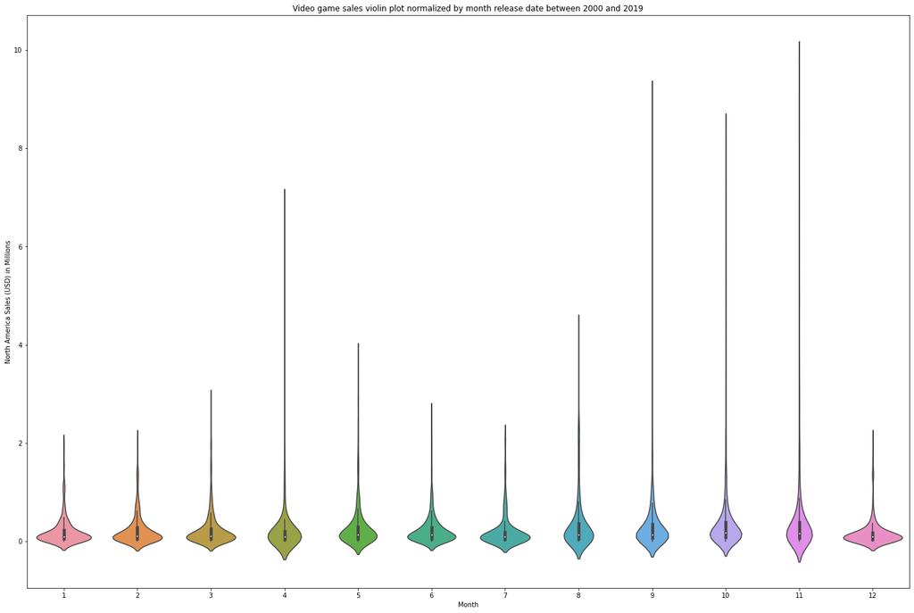

```python
binned_vg_sales['release_month'] = pd.to_datetime(binned_vg_sales.Release_Date).dt.month

fig, ax = plt.subplots(figsize=(24,16))

sns.violinplot(x=binned_vg_sales.release_month, y=binned_vg_sales.NA_Sales)

# Set proper labels for month and sales
ax.set_xlabel('Month')
ax.set_ylabel('North America Sales (USD) in Millions')
plt.title("Video game sales violin plot normalized by month release date between 2000 and 2019")
plt.show()
```

### Analysis

Here we can see a slightly different trend for release month of a video game. Video games that sell well tend to be in quarter 4. The most mid-heavy plots seem to be February, March, and December, meaning that video games released in these times do not sell too well. The plots with the highest means are April, September, October, and November, making these the best months to release a video game. November makes the most sense since most people purchase their gifts for Christmas around that time. Video game sales seem to follow seasons. April is around when Summer starts in some states, boosting sales, and then October is about when Winter starts, giving people more time inside to play video games. Then November is the holiday season, boosting gifted video game sales. December does not likely sell well because most of the sales were collected in November. Releasing a video game in December likely misses the sales rush and is not efficient.

Lets try to form a linear regression based on release month.

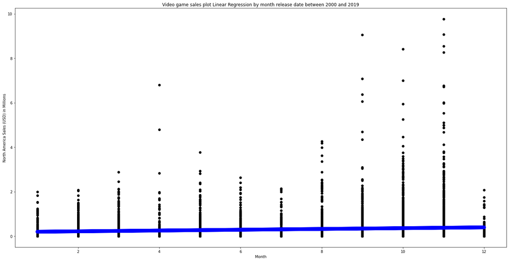

```python
X = binned_vg_sales.release_month.values
y = binned_vg_sales.NA_Sales.values

X = X.reshape(len(X), 1)
y = y.reshape(len(y), 1)

# Using sklearn LinearRegression to fit data
regr = linear_model.LinearRegression()
regr.fit(X, y)

# Plot regression line along with data from exercise 1
x_prediction = regr.predict(X)
fig, ax = plt.subplots(figsize=(24,12))
plt.scatter(X, y,  color='black')
plt.plot(X, x_prediction, color='blue', linewidth=10)

# Set proper labels for month and sales
ax.set_xlabel('Month')
ax.set_ylabel('North America Sales (USD) in Millions')
plt.title("Video game sales plot Linear Regression by month release date between 2000 and 2019")
plt.show()
```

### Analysis

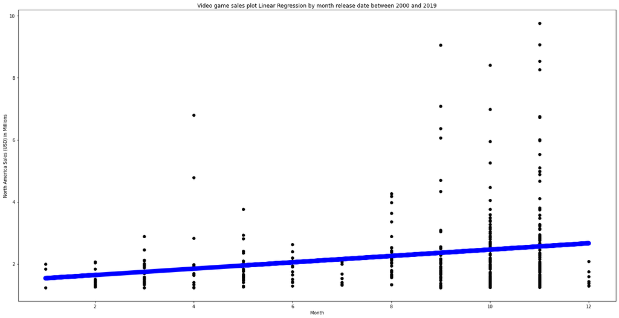

```python
binned_vg_sales_top_10p = pd.DataFrame(binned_vg_sales)

# Removing any sales data that is not in the top 10%
binned_vg_sales_top_10p = binned_vg_sales_top_10p[binned_vg_sales_top_10p.NA_Sales > binned_vg_sales_top_10p.NA_Sales.quantile(.95)]

X = binned_vg_sales_top_10p.release_month.values
y = binned_vg_sales_top_10p.NA_Sales.values

X = X.reshape(len(X), 1)
y = y.reshape(len(y), 1)

# Using sklearn LinearRegression to fit data
regr = linear_model.LinearRegression()
regr.fit(X, y)

# Plot regression line along with data from exercise 1
x_prediction = regr.predict(X)
fig, ax = plt.subplots(figsize=(24,12))
plt.scatter(X, y,  color='black')
plt.plot(X, x_prediction, color='blue', linewidth=10)

# Set proper labels for month and sales
ax.set_xlabel('Month')
ax.set_ylabel('North America Sales (USD) in Millions')
plt.title("Video game sales plot Linear Regression by month release date between 2000 and 2019")
plt.show()
```

### Analysis

Here we can better see that the linear regression is increasing, furthur enforcing the trend that games released later in the year are more successful than games released earlier in the year. We will now calculate a statistical model using statsmodels.formula.api to see how strong this relationship is.

```python
# Getting residual model
statistic_model = smf.ols(formula="NA_Sales ~ release_month ", data=binned_vg_sales_top_10p).fit()
print(statistic_model.summary())

# Pulling residual data from model
binned_vg_sales_top_10p['predictedSales'] = statistic_model.resid
```

```
                            OLS Regression Results
==============================================================================
Dep. Variable:               NA_Sales   R-squared:                       0.047
Model:                            OLS   Adj. R-squared:                  0.044
Method:                 Least Squares   F-statistic:                     18.01
Date:                Tue, 20 Jul 2021   Prob (F-statistic):           2.79e-05
Time:                        06:56:15   Log-Likelihood:                -628.32
No. Observations:                 368   AIC:                             1261.
Df Residuals:                     366   BIC:                             1268.
Df Model:                           1
Covariance Type:            nonrobust
=================================================================================
                    coef    std err          t      P>|t|      [0.025      0.975]
---------------------------------------------------------------------------------
Intercept         1.4350      0.215      6.682      0.000       1.013       1.857
release_month     0.1025      0.024      4.244      0.000       0.055       0.150
==============================================================================
Omnibus:                      231.483   Durbin-Watson:                   1.253
Prob(Omnibus):                  0.000   Jarque-Bera (JB):             1632.176
Skew:                           2.710   Prob(JB):                         0.00
Kurtosis:                      11.779   Cond. No.                         27.7
==============================================================================

Notes:
[1] Standard Errors assume that the covariance matrix of the errors is correctly specified.
```

### Analysis

The calculated p-value of the smaller subset is 2.79e-05, which is not large, but neither is it very small like the previously calculated p-value between release date and quarter. This means that while there is a linear relationship between month and sales, it is not too strong (it is not guaranteed that each month, sales will be higher than the last). Our data is more likely just skewed towards the holiday months (October-November) and not necessarily linear since sales between January and October fluctuate a lot, which means that their sales is attributed to more than just release date.

I am expecting to see sales rise as rating rises and for the top selling genres to be action, adventure, and shooter.

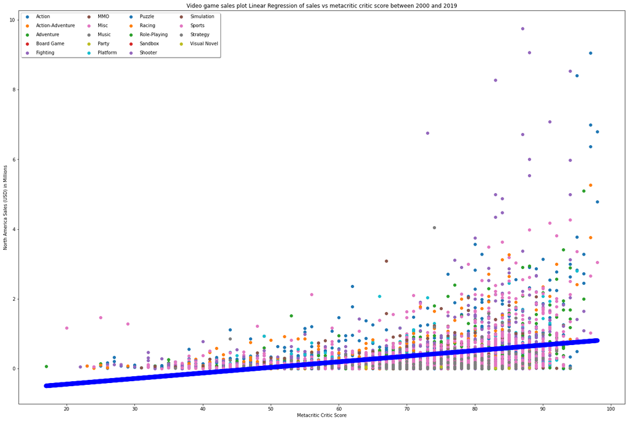

```python
fig, ax = plt.subplots(figsize=(24,16))

# Group by platform and generation
for label, group in metacritic_vgchartz_df.groupby(['Genre']):
    ax.scatter(group['Critic_Score'], group['NA_Sales'], label=label)

ax.legend(ncol=4,
           labelspacing=1.0,
           handletextpad=1.0, handlelength=2.0,
           fancybox=True, shadow=True)

X = metacritic_vgchartz_df.Critic_Score.values
y = metacritic_vgchartz_df.NA_Sales.values

X = X.reshape(len(X), 1)
y = y.reshape(len(y), 1)

# Using sklearn LinearRegression to fit data
regr = linear_model.LinearRegression()
regr.fit(X, y)

# Plot regression line along with data from exercise 1
x_prediction = regr.predict(X)
plt.plot(X, x_prediction, color='blue', linewidth=10)

# Set proper labels for rating and sales
ax.set_xlabel('Metacritic Critic Score')
ax.set_ylabel('North America Sales (USD) in Millions')
plt.title("Video game sales plot Linear Regression of sales vs metacritic critic score between 2000 and 2019")
plt.show()
```

### Analysis

```
                            OLS Regression Results
==============================================================================
Dep. Variable:               NA_Sales   R-squared:                       0.113
Model:                            OLS   Adj. R-squared:                  0.113
Method:                 Least Squares   F-statistic:                     641.0
Date:                Tue, 20 Jul 2021   Prob (F-statistic):          3.05e-133
Time:                        06:56:16   Log-Likelihood:                -4720.4
No. Observations:                5049   AIC:                             9445.
Df Residuals:                    5047   BIC:                             9458.
Df Model:                           1
Covariance Type:            nonrobust
================================================================================
                   coef    std err          t      P>|t|      [0.025      0.975]
--------------------------------------------------------------------------------
Intercept       -0.7714      0.045    -17.046      0.000      -0.860      -0.683
Critic_Score     0.0161      0.001     25.318      0.000       0.015       0.017
==============================================================================
Omnibus:                     5802.118   Durbin-Watson:                   1.232
Prob(Omnibus):                  0.000   Jarque-Bera (JB):           712238.483
Skew:                           5.920   Prob(JB):                         0.00
Kurtosis:                      59.968   Cond. No.                         372.
==============================================================================

Notes:
[1] Standard Errors assume that the covariance matrix of the errors is correctly specified.
```

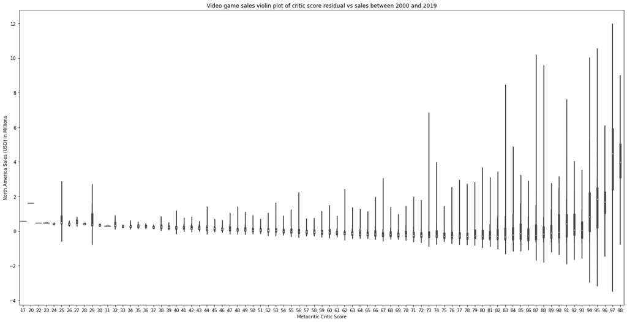

```python
# Getting residual model
statistic_model = smf.ols(formula="NA_Sales ~ Critic_Score ", data=metacritic_vgchartz_df).fit()
print(statistic_model.summary())

# Pulling residual data from model
metacritic_vgchartz_df['predictedSales'] = statistic_model.resid

fig, ax = plt.subplots(figsize=(24,12))
sns.violinplot(x=metacritic_vgchartz_df.Critic_Score, y=metacritic_vgchartz_df.predictedSales)

# Set proper labels for genre and sales
ax.set_xlabel('Metacritic Critic Score')
ax.set_ylabel('North America Sales (USD) in Millions')
plt.title("Video game sales violin plot of critic score residual vs sales between 2000 and 2019")
plt.show()
```

### Analysis

We can see here a very low P-Value of 3.05e-133. This means that the relationship between sales and ratings is extremely strong and as critic ratings go up, sales usually go up. This can also be seen by the increased expected sales as critic score goes up in the residual violin plot. We will now take a closer look at the trend in genres to see which genre sells best on average using a violin plot and the previously calculated model residual.

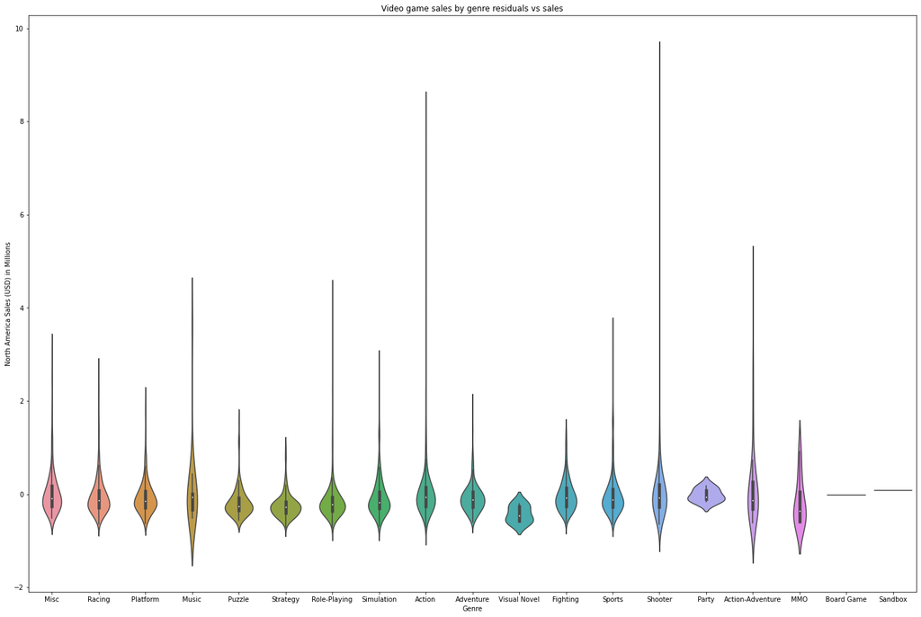

```python
fig, ax = plt.subplots(figsize=(24,16))

ax = sns.violinplot(x=metacritic_vgchartz_df.Genre, y=metacritic_vgchartz_df.predictedSales)

# Set proper labels for rating and sales
ax.set_xlabel('Genre')
ax.set_ylabel('North America Sales (USD) in Millions')
plt.title("Video game sales by genre residuals vs sales")
plt.show()
```

### Analysis

There is no linear relationship here since every genre is different. What about genre's affect on rating? Which could in turn affect sales.

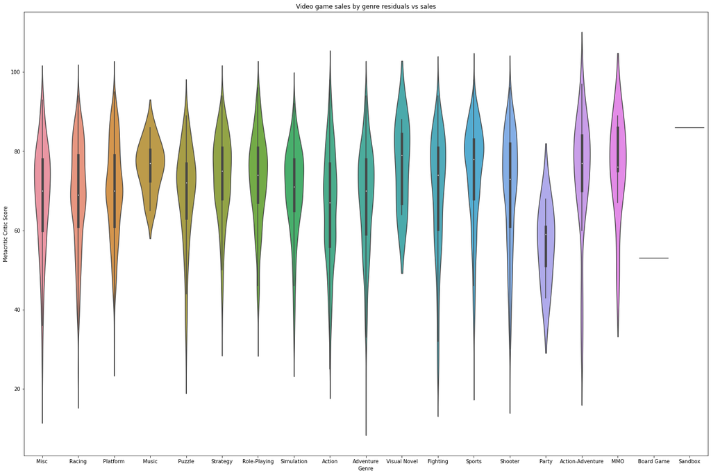

```python
fig, ax = plt.subplots(figsize=(24,16))

ax = sns.violinplot(x=metacritic_vgchartz_df.Genre, y=metacritic_vgchartz_df.Critic_Score)

# Set proper labels for rating and sales
ax.set_xlabel('Genre')
ax.set_ylabel('Metacritic Critic Score')
plt.title("Video game sales by genre residuals vs sales")
plt.show()
```

### Analysis

We can see here that genre has little effect on rating as well. Genres such as Action-Adventure do have higher means, but for the most part, the genres all have means around 70-80 critic score.

So we will focus on sales as a function of release date and critic score and continue onto the last metric we will look at: does the time it takes to beat a game have an affect on sales?

I am expecting to see very little effect on sales from playtime because story-rich games can be short while open world games can be long, and both usually equally sell well.

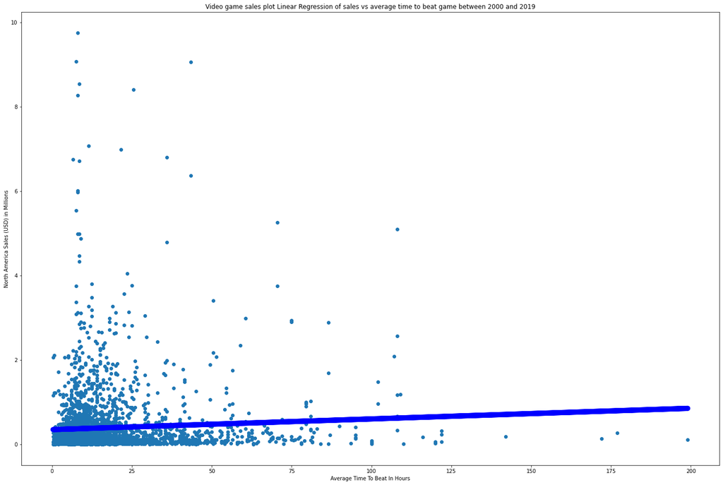

```python
fig, ax = plt.subplots(figsize=(24,16))

# No grouping needed since we already explored trends with platforms and genres
ax.scatter(final_vg_df['Average_Time_To_Beat_Between_All_Playstyles'], final_vg_df['NA_Sales'], label=label)

X = final_vg_df.Average_Time_To_Beat_Between_All_Playstyles.values
y = final_vg_df.NA_Sales.values

X = X.reshape(len(X), 1)
y = y.reshape(len(y), 1)

# Using sklearn LinearRegression to fit data
regr = linear_model.LinearRegression()
regr.fit(X, y)

# Plot regression line along with data from exercise 1
x_prediction = regr.predict(X)
plt.plot(X, x_prediction, color='blue', linewidth=10)

# Set proper labels for rating and sales
ax.set_xlabel('Average Time To Beat In Hours')
ax.set_ylabel('North America Sales (USD) in Millions')
plt.title("Video game sales plot Linear Regression of sales vs average time to beat game between 2000 and 2019")
plt.show()
```

### Analysis

As expected, there is no clear trend between the time to beat a game and sales. You can make a game that takes over 100 hours to beat, but still sell far less than a million copies. This means that the biggest effect on sales are release date and critic scores.

Most best sellers have around 10 hours of playtime, which is a decent length for a game. After 50 hours, games are not likely to sell well. Personally, I find that 30 hours is the sweet spot for a good story rich game.

Just to make sure we are not missing any relationship, we will calculate the P-Value.

```python
# Getting residual model
statistic_model = smf.ols(formula="NA_Sales ~ Average_Time_To_Beat_Between_All_Playstyles ", data=final_vg_df).fit()
print(statistic_model.summary())

# Pulling residual data from model
final_vg_df['predictedSales'] = statistic_model.resid
```

```
                            OLS Regression Results
==============================================================================
Dep. Variable:               NA_Sales   R-squared:                       0.004
Model:                            OLS   Adj. R-squared:                  0.003
Method:                 Least Squares   F-statistic:                     10.94
Date:                Tue, 20 Jul 2021   Prob (F-statistic):           0.000951
Time:                        06:56:19   Log-Likelihood:                -3539.4
No. Observations:                3114   AIC:                             7083.
Df Residuals:                    3112   BIC:                             7095.
Df Model:                           1
Covariance Type:            nonrobust
===============================================================================================================
                                                  coef    std err          t      P>|t|      [0.025      0.975]
---------------------------------------------------------------------------------------------------------------
Intercept                                       0.3532      0.019     19.032      0.000       0.317       0.390
Average_Time_To_Beat_Between_All_Playstyles     0.0025      0.001      3.308      0.001       0.001       0.004
==============================================================================
Omnibus:                     3484.191   Durbin-Watson:                   1.156
Prob(Omnibus):                  0.000   Jarque-Bera (JB):           302909.527
Skew:                           5.738   Prob(JB):                         0.00
Kurtosis:                      49.935   Cond. No.                         33.4
==============================================================================

Notes:
[1] Standard Errors assume that the covariance matrix of the errors is correctly specified.
```

## Final Thoughts

While I did not have time to get into more metrics that effect success such as advertising, "hype," controversy, and sales, it is still possible to measure these metrics, albiet far more work.

To measure advertising, a new dataset would have to be made that tracks a games advertising budget (For example, Cyberpunk 2077 had an advertising budget of 1.2 billion PLN or roughly $316,131,480 USD, and it sold extremely well despite having bad ratings). This dataset would need a lot of work and research since advertising budget is not often public.

Measuring video game "hype" and controversy is a little trickier, requiring more assumptions and language processing. Tracking trending Twitter hashtags is one way to find if a game is hyped. Monitoring subreddit activity for a game's subreddit (if one exists) or looking at the number of posts that are made about a game is another great way to track hype. Games that are hyped will very often have a lot of popular posts with their trailers and gameplay shots. Controversy is similar, but would require searching for key words in relation to a game's posts like "disappointing," "worst game ever," "this is why I don't preorder," and so on.

The last metric I wanted to look at but did not have time is the effect of christmas sales on video game sales. Does putting a video game on sale during the holidays for \$10 off result in a significant increase in sales when compared to games that do not go on sale. What is the best price for a video game? Is \\$60 too much? These are questions that you, the reader can answer, by just doing more digging into datasets or making your own!

Another interesting topic to cover is the effect of COVID-19 on video game sales, given that more people are at home.